# Computational Exercise 3.1: Estimating and plotting a selection surface

### 2012 Stevan J. Arnold

## Get your data into R using the following steps.

Save the file radix5.txt to your desktop or folder of choice In the following example, we have created a folder called ?R wd? and placed the data file in it Now, set your working directory using a statement comparable to this one Be sure and use the / not the \ spacing convention!

```r
# setwd('set working directory here')
```

Now read in your data

```r
thamnophis = read.table("radix5.txt", header = T)
# Print out the data frame to make sure it looks OK
head(thamnophis)
```

```
##   LITTER NAME   SPEED BODY TAIL
## 1    761    1 0.16207  154   77
## 2    761    3 0.09019  149   70
## 3    761    4 0.10823  153   69
## 4    761    5 0.27609  154   73
## 5    761    6 0.13532  150   72
## 6    761    8 0.20325  149   68
```

## Stage 1: Estimating the selection gradients

```r
new.body = mean(thamnophis$BODY) - thamnophis$BODY
new.tail = mean(thamnophis$TAIL) - thamnophis$TAIL
new.speed = thamnophis$SPEED/sd(thamnophis$SPEED)
```

What do these transformations do to the mean and standard deviation of the variables? Find out by using statements like 'mean(new.body), sd(new.body)'. Let's begin by fitting a plane to the transformed data

```r
model1 <- lm(new.speed ~ new.body + new.tail)
```

print out the coefficients and statistics of the fit this output will give us our best estimates of the directional selection gradients for new.body and new.tail

```r
summary(model1)
```

```
##
## Call:
## lm(formula = new.speed ~ new.body + new.tail)
##
## Residuals:
##     Min      1Q  Median      3Q     Max
## -2.2202 -0.6755  0.0165  0.7030  2.4108
##
## Coefficients:
##             Estimate Std. Error t value Pr(>|t|)
## (Intercept)  2.62196    0.08393   31.24   <2e-16 ***
## new.body    -0.02435    0.02497   -0.98     0.33
## new.tail    -0.00131    0.02800   -0.05     0.96
## ---
## Signif. codes:  0 '***' 0.001 '**' 0.01 '*' 0.05 '.' 0.1 ' ' 1
##
## Residual standard error: 1 on 140 degrees of freedom
## Multiple R-squared:  0.00684,    Adjusted R-squared:  -0.00734
## F-statistic: 0.482 on 2 and 140 DF,  p-value: 0.618
```

Now, fit a full quadratic model to the data, remembering to use the factor of 0.5 for the stabilizing selection gradients Create a new variable called prod which is the product of new.body and new.tail

```r
prod = new.body * new.tail
```

Then fit the quadratic model

```r
model2 <- lm(new.speed ~ new.body + new.tail + I(0.5 * new.body^2) + I(0.5 *
    new.tail^2) + prod)
summary(model2)
```

```
##
## Call:
## lm(formula = new.speed ~ new.body + new.tail + I(0.5 * new.body^2) +
##     I(0.5 * new.tail^2) + prod)
##
## Residuals:
##     Min      1Q  Median      3Q     Max
## -2.2180 -0.6022  0.0418  0.6727  2.4024
##
## Coefficients:
##                     Estimate Std. Error t value Pr(>|t|)
## (Intercept)          2.62844    0.11395   23.07   <2e-16 ***
## new.body            -0.02759    0.02489   -1.11    0.270
## new.tail             0.00809    0.02800    0.29    0.773
## I(0.5 * new.body^2) -0.00243    0.00914   -0.27    0.791
## I(0.5 * new.tail^2) -0.00171    0.01336   -0.13    0.899
## prod                 0.02031    0.00789    2.57    0.011 *
## ---
## Signif. codes:  0 '***' 0.001 '**' 0.01 '*' 0.05 '.' 0.1 ' ' 1
##
## Residual standard error: 0.99 on 137 degrees of freedom
## Multiple R-squared:  0.0537, Adjusted R-squared:  0.0192
## F-statistic: 1.56 on 5 and 137 DF,  p-value: 0.177
```

In summary, using z1 for body and z2 for tail, we have from the results above, the following values for selection gradients

```r
beta1 = coef(model1)[2]
beta2 = coef(model1)[3]
gamma11 = coef(model2)[4]
gamma22 = coef(model2)[5]
gamma12 = coef(model2)[6]
```

## Stage 2: Plotting the selection surface, an ISS

Set the parameters for a full quadratic fitness surface for two traits

```r
z1 = new.body
z2 = new.tail
```

Set the value for the intercept of the surface when z1=z2=0

```r
alpha = 1
```

Define a function called fit that will compute the value of fitness as a function of z1 and z2

```r
fit <- function(z1, z2, alpha, beta1, beta2, gamma11, gamma22, gamma12) alpha +
    (beta1 * z1) + (beta2 * z2) + (gamma11 * 0.5 * (z1^2)) + (gamma22 * 0.5 *
    (z2^2)) + (gamma12 * (z1 * z2))
```

Define a series of values for z1 and z2 that will be used to compute the value of relative fitness on the surface

```r
x <- seq(-2, 2, length = 30)
y <- seq(-2, 2, length = 30)
```

Compute the surface values of relative fitness using the x-y grid of values for z1 and z2 for later use by the surface plotting function called persp We could use the fit function to compute values of fitness but instead we will use a #function, called outer, that is more compatible with persp The function outer has some specific requirements so we oblige by writing our fitness function in the following form

```r
z <- outer(x, y, function(a, b, alpha, beta1, beta2, gamma11, gamma22, gamma12) 1 +
    (-0.024351 * a) + (-0.001307 * b) + (-0.002425 * 0.5 * (a^2)) + (-0.001705 *
    0.5 * (b^2)) + (0.020315 * (a * b)))
```

Define two variables that give the number of rows and cols in z

```r
nrz <- nrow(z)
ncz <- ncol(z)
```

Create a function interpolating colors in the range of specified colors

```r
jet.colors <- colorRampPalette(c("yellow", "orange"))
```

Generate the desired number of colors from this palette

```r
nbcol <- 100
color <- jet.colors(nbcol)
```

Compute the z-value at the facet centres

```r
zfacet <- z[-1, -1] + z[-1, -ncz] + z[-nrz, -1] + z[-nrz, -ncz]
```

Recode facet z-values into color indices

```r
facetcol <- cut(zfacet, nbcol)
```

Finally, plot the ISS

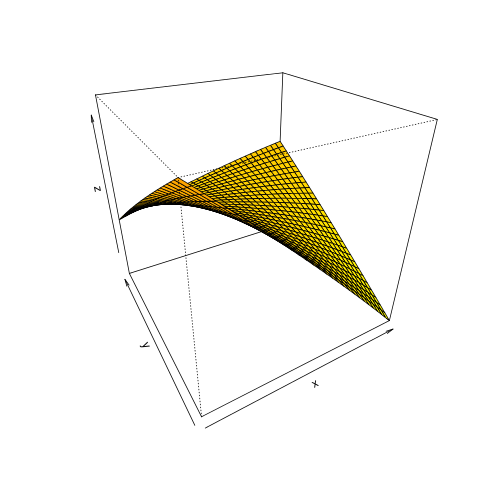

```r
par(bg = "white")

persp(x, y, z, col = color[facetcol], phi = 30, theta = -30)
```

For another view of the surface, do a simple contour plot

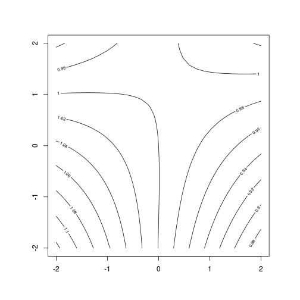

```r
par(pty = "s")
contour(x, y, z)
```

Let's plot the eigenvectors of the gamma-matrix on this contour plot First, let?s define the matrix

```r
gamma = matrix(c(gamma11, gamma12, gamma12, gamma22), nrow = 2, ncol = 2)
gamma
```

```
##           [,1]      [,2]
## [1,] -0.002425  0.020315
## [2,]  0.020315 -0.001705
```

```r
eigen(gamma)
```

```
## $values
## [1]  0.01825 -0.02238
##
## $vectors
##         [,1]    [,2]
## [1,] -0.7008 -0.7133
## [2,] -0.7133  0.7008
```

Next, let?s setup the beta vector and check to see if its values are correct

```r
beta = matrix(c(beta1, beta2), nrow = 2, ncol = 1)
beta
```

```
##           [,1]
## [1,] -0.024351
## [2,] -0.001307
```

Using gamma and beta, we can solve for the stationary point on the surface using expression(11) from Phillips & Arnold 1989

```r
z.zero = -(solve(gamma)) %*% beta
```

Plot the stationary point on the surface

```r
points(z.zero[1, 1], z.zero[2, 1])
```

[output not shown]

```
## Error: plot.new has not been called yet
```

Finally, plot the eigenvectors on the surface First one eigenvector

```r
delx1 = z.zero[1] + 6 * eigen(gamma)$vectors[1, 2]
delx2 = z.zero[2] + 6 * eigen(gamma)$vectors[2, 2]
delx11 = z.zero[1] - 6 * eigen(gamma)$vectors[1, 2]
delx22 = z.zero[2] - 6 * eigen(gamma)$vectors[2, 2]
x.values = c(delx1, z.zero[1], delx11)
y.values = c(delx2, z.zero[2], delx22)
lines(x.values, y.values, lty = 2, lwd = 2)
```

[output not shown]

```
## Error: plot.new has not been called yet
```

then the other

```r
delx1 = z.zero[1] + 6 * eigen(gamma)$vectors[1, 1]
delx2 = z.zero[2] + 6 * eigen(gamma)$vectors[2, 1]
delx11 = z.zero[1] - 6 * eigen(gamma)$vectors[1, 1]
delx22 = z.zero[2] - 6 * eigen(gamma)$vectors[2, 1]
x.values = c(delx1, z.zero[1], delx11)
y.values = c(delx2, z.zero[2], delx22)
lines(x.values, y.values, lty = 2, lwd = 2)
```

[output not shown]

```
## Error: plot.new has not been called yet
```

Which of these eigenvectors is gamma max? Now, let?s estimate the omega-matrix, approximating it as the negative inverse of the gamma-matrix

```r
omega = -(solve(gamma))
omega
```

```
##         [,1]    [,2]
## [1,]  -4.173 -49.723
## [2,] -49.723  -5.936
```

It's eigenvectors should be the same as those of the gamma-matrix Let's check

```r
eigen(omega)
```

```
## $values
## [1]  44.68 -54.79
##
## $vectors
##         [,1]   [,2]
## [1,] -0.7133 0.7008
## [2,]  0.7008 0.7133
```

What is the interpretation of these eigenvalues on the contour plot?

## Stage 3: Can you build a loop that will show the contour plot while bootstrapping #over the snake sample? Here?s an example of script that does that!

We begin by writing a function that we will use during bootstrapping to estimate the coefficients that describe the surface for a particular boot sample

```r
est.coeff = function(y, x1, x2) {
    prod = x1 * x2
    m1 = lm(y ~ x1 + x2)
    m2 = lm(y ~ x1 + x2 + I(0.5 * x1^2) + I(0.5 * x2^2) + prod)
    c(m1$coeff[2], m1$coeff[3], m2$coeff[4], m2$coeff[5], m2$coeff[6])
}
```

Next, we program a perspective plot function

```r
x <- seq(-2, 2, length = 30)
y <- seq(-2, 2, length = 30)
```

Compute the surface values of relative fitness using the x-y grid of values for z1 and z2 for later use by the surface plotting function called persp We could use the fit function to compute values of fitness but instead we will use a #function, called outer, that is more compatible with persp The function outer has some specific requirements so we oblige by writing our fitness function in the following form Write a function that plots the perspective plot for each bootstrap

```r
persp.boot = function(b1, b2, y1, y2, y12, x = seq(-10, 10, length = 30), y = seq(-10,
    10, length = 30)) {
    z <- outer(x, y, function(a, b, alpha, beta1, beta2, gamma11, gamma22, gamma12) 1 +
        (b1 * a) + (b2 * b) + (y1 * 0.5 * (a^2)) + (y2 * 0.5 * (b^2)) + (y12 *
        (a * b)))
    nrz <- nrow(z)
    ncz <- ncol(z)
    jet.colors <- colorRampPalette(c("yellow", "orange"))
    nbcol <- 100
    color <- jet.colors(nbcol)
    zfacet <- z[-1, -1] + z[-1, -ncz] + z[-nrz, -1] + z[-nrz, -ncz]
    facetcol <- cut(zfacet, nbcol)
    par(bg = "white")
    persp(x, y, z, col = color[facetcol], phi = 30, theta = -30)
}
```

Test it out

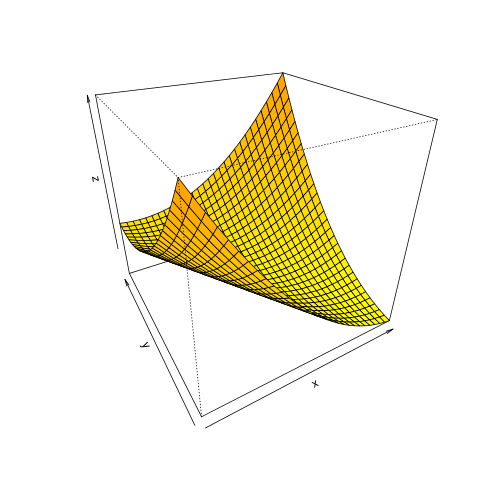

```r
persp.boot(-2, 2, 1, 1, 1)
```

Bootstrap over individuals

```r
par(ask = FALSE)
n = length(new.body)
for (i in 1:100) {
    samp = sample(1:n, n, replace = TRUE)
    boot.speed = new.speed[samp]
    boot.body = new.body[samp]
    boot.tail = new.tail[samp]
    boot.coeff = est.coeff(boot.speed, boot.body, boot.tail)
    persp.boot(boot.coeff[1], boot.coeff[2], boot.coeff[3], boot.coeff[4], boot.coeff[5],
        x = seq(-10, 10, length = 10), y = seq(-10, 10, length = 10))
    Sys.sleep(0.1)
}
```

[figure not shown]

## Stage 4: Let's build a loop that will show the contour plot while bootstrapping over the snake sample while rotating the surface about this vertical axis?

First, let's make the perspective plot rotate

```r
k = 100
for (i in 1:k) {
    persp(x, y, z, col = color[facetcol], phi = 30, theta = -(30 + (3.3 * i)))
}
```

To make the plot rotate while bootstrapping we first write a new function that plots the perspective plot for each bootstrap

```r
i = 1
persp.boot = function(b1, b2, y1, y2, y12, x = seq(-10, 10, length = 30), y = seq(-10,
    10, length = 30)) {
    z <- outer(x, y, function(a, b, alpha, beta1, beta2, gamma11, gamma22, gamma12) 1 +
        (b1 * a) + (b2 * b) + (y1 * 0.5 * (a^2)) + (y2 * 0.5 * (b^2)) + (y12 *
        (a * b)))
    nrz <- nrow(z)
    ncz <- ncol(z)
    jet.colors <- colorRampPalette(c("yellow", "orange"))
    nbcol <- 100
    color <- jet.colors(nbcol)
    zfacet <- z[-1, -1] + z[-1, -ncz] + z[-nrz, -1] + z[-nrz, -ncz]
    facetcol <- cut(zfacet, nbcol)
    par(bg = "white")
    persp(x, y, z, col = color[facetcol], phi = 30, theta = -30 + (3.3 * i))
}
```

Not let's run the bootstrapping during the rotation

```r
par(ask = FALSE)
n = length(new.body)
k = 100
for (i in 1:k) {
    samp = sample(1:n, n, replace = TRUE)
    boot.speed = new.speed[samp]
    boot.body = new.body[samp]
    boot.tail = new.tail[samp]
    boot.coeff = est.coeff(boot.speed, boot.body, boot.tail)
    persp.boot(boot.coeff[1], boot.coeff[2], boot.coeff[3], boot.coeff[4], boot.coeff[5],
        x = seq(-10, 10, length = 10), y = seq(-10, 10, length = 10))
    Sys.sleep(0.2)
}
```

[figure not shown]